# 함수추정 및 실습 HW3

김보창

```r
set.seed(123)
```

실행할때마다 동일한 결과가 나오도록 set.seed를 통해 시드를 설정해준다.

## Q1

### 1-(a)

```r
mykrig1<-function(nd, ne, xx, yy, ex, bw)
{
# (1)
  full <- matrix(0, nd, nd)
  full[lower.tri(full)] <- dist(xx)
  dist1 <- full + t(full)
  cc <- exp( - dist1^2/bw^2)
# (2)
  dvector <- function(exs, xx, bw)
  {
    dv <- exp( - (exs - xx)^2/bw^2)
    return(dv)
  }
  dmat <- apply(matrix(ex, nrow = 1), 2, dvector, xx = xx,
    bw = bw)
# (3)
  ccr <- solve(cc)
  ccs <- sum(apply(ccr, 2, sum))
  chi <- (-2 * (1 - apply((ccr %*% dmat), 2, sum)))/ccs
  chimat <- matrix(rep(chi, times = nd), ncol = ne,
    byrow = T)
# (4)
  ww <- ccr %*% (dmat - 0.5 * chimat)
  ey <- t(ww) %*% yy
# (5)
  return(ey)
}
```

먼저, 교재의 4장 (E) 부분에 해당하는 코드를 이용하여 ordinary kriging을 구해주는 함수를 구현하였다.

여기서 kriging에 사용하는 theoretical correlogram은

gaussian correlogram으로, 다음과 같다.

$Correlo(r) = \text{exp}(-(\frac{r}{\delta})^2)$

위 함수는 데이터인 xx, yy와 데이터의 개수인 nd, 추정할 데이터의 위치인 ex와 그 개수인 ne, 그리고 위의 theoretical correlogram에서 사용할 $\delta$를 받아 ex의 위치에서 ordinary kriging된 결과를 리턴해주는 함수이다.

cross validation 값의 정의는 아래와 같다.

$$C V[\hat{m}(x)]=\frac{\sum_{k=1}^{n}\left(Y_{k}-\hat{m}^{-k}\left(X_{k}\right)\right)^{2}}{n}$$

문제에서 원하는것은, 이 cross validation을 구할때 양 끝점을 제외하는 경우는 사용하지 않을것이므로, 위의 정의를 다시 아래와 같이 바꿔서 사용할 것이다.

$$C V[\hat{m}(x)]=\frac{\sum_{k=2}^{n-1}\left(Y_{k}-\hat{m}^{-k}\left(X_{k}\right)\right)^{2}}{n}, X_1 \le X_2 ... \le X_n$$

이제, 위 정의대로 cross validation을 구해주는 함수를 짜자.

cross validation을 구할때, 양 끝점을 제외해야하므로 X들이 sorting된 상태여야하고, 따라서 sorting을 해주었다.

아래 함수는 xdata와 ydata, 그리고 bandwidth들을 받아서 각 bandwidth에 해당하는 CV값들을 리턴해준다.

```r
cv_ord_krig<-function(xdata, ydata, bws)
{
    nd <- length(ydata)

    ydata <- ydata[order(xdata)]
    xdata <- xdata[order(xdata)]
    #sort by ascending order. order of ydata, xdata is important!!


    get_krig_cv <- function(bw, x1, y1)
    {
        cv <- 0
        nd <- length(y1)

        if(nd < 3) return(NULL) # we can't get cv

        for(i in seq(from = 2, to = nd-1))
        {
            xdata <- x1[-i]
            ydata <- y1[-i]
            remain_xdata <- x1[i]
            remain_ydata <- y1[i]
            estim_y <- mykrig1(nd-1, 1, xdata, ydata, as.vector(remain_xdata), bw)
            cv <- cv + sum((remain_ydata - estim_y)**2)
        }

        cv <- cv / (nd - 2)
        return(cv)
    }


    cvlst <- lapply(as.list(bws),get_krig_cv, x1 = xdata, y1 = ydata)
    cvlst <- unlist(cvlst)
    return(cvlst)
}
```

아래함수는 bandwidth와 cv array를 받아서 그래프를 출력해주는 함수다.

```r
plot_cv <- function(bandwidth_array, cv_array, description = "")
{
    par(mfrow = c(1, 1))
    plot(bandwidth_array, cv_array, type = "n",
     xlab = "bandwidth", ylab = "CV", main = description)
    points(bandwidth_array, cv_array, pch = 1, cex = 0.5)
    #lines(smtparam_array, cv_array, lwd = 1)
    pcvmin <- seq(along = cv_array)[cv_array == min(cv_array, na.rm = TRUE)]
    spancv <- bandwidth_array[pcvmin]
    cvmin <- cv_array[pcvmin]
    points(spancv, cvmin, cex = 1, pch = 15, col = "red")
}
```

plot graph함수는 xdata, ydata, smtparam을 받아 xdata의 위치에서 추정된 값을 리턴하는 estimate_func을 받아서, 원래 데이터를 점으로, estimate된 결과를 파란 선으로 그려준다.

```r
plot_graph <- function(estimate_func, xdata, ydata, smtparam, description = "")
{
    par(mfrow=c(1,1))
    estimated_y <- estimate_func(xdata, ydata, smtparam)
    plot(xdata, ydata , xlab = "X", ylab = "Y", type = "p", main = description, sub = sprintf("using smtparam : %f", smtparam))
    lines(xdata, estimated_y, col = "blue")
}
```

위 함수를 사용하기 위해 다음과 같이 estimate 함수를 정의한다.

```r
estimate_ord_krig <- function(xdata, ydata, bw)
{
    nd <- length(ydata)
    return(mykrig1(nd, nd, xdata, ydata, xdata, bw))
}
```

마지막으로, xdata와 ydata, bandwidth 목록을 받아서 이중 가장 CV값이 낮은 bandwidth를 사용한 kriging 그래프를 출력해주는 함수를 다음과 같이 구현하였다.

```r
full_test_kriging <- function(xdata, ydata, smtparam_array, description = "")
{
    cv_array <- cv_ord_krig(xdata, ydata, smtparam_array)
    plot_cv(smtparam_array, cv_array, description)

    smt_idx <- which(cv_array == min(cv_array, na.rm = TRUE))
    if(length(smt_idx) > 1)
    {
        smt_idx <- smt_idx[1]
    }
    best_smt <- smtparam_array[smt_idx]


    plot_graph(estimate_ord_krig, xdata, ydata, best_smt, description = description)
}
```

### 1-(b)

problem 2.3의 chapter 2의 데이터는 eqispaced data로, x값으로 1,2…의 값을 가지게 된다.

해당 데이터를 생성하고, 위 함수를 이용하여 가장 CV값을 낮게 만드는 $\delta$를 찾자.

delta의 값으로는 0.01~2까지, 0.01 간격의 값을 주었다.

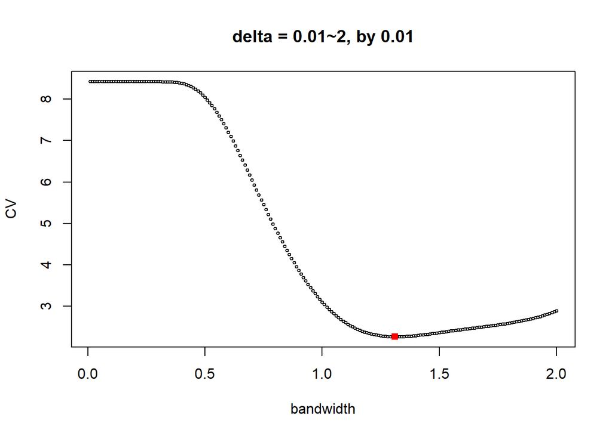

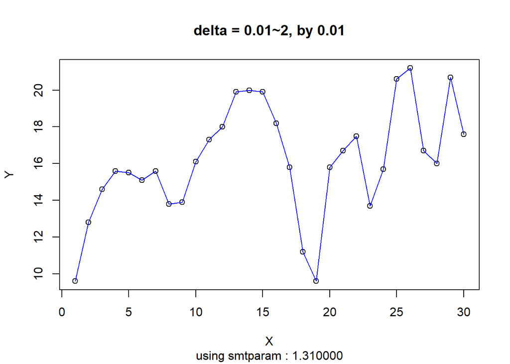

```r
ydata <- c(9.6, 12.8, 14.6, 15.6 ,15.5 ,15.1, 15.6, 13.8, 13.9, 16.1, 17.3, 18, 19.9, 20, 19.9, 18.2, 15.8, 11.2, 9.6, 15.8, 16.7, 17.5, 13.7, 15.7, 20.6, 21.2, 16.7, 16, 20.7, 17.6)
xdata <- seq_len(length(ydata))


full_test_kriging(xdata, ydata, seq(0.01,2,by = 0.01), description = "delta = 0.01~2, by 0.01")
```

위에서 알 수 있듯이, $\delta = 1.31$에서 CV가 가장 작고, 이 값을 이용하여 ordinary criging을 한 결과로 출력된 그래프는 위와 같다.

## Q2

### 2-(a)

모델이 다음과 같은 simple kriging에서의 Hat matrix를 구하고, Hat matrix의 성분들을 plot해주는 함수를 만들자.

모델은 다음과 같다.

$$y_i = e_i = e_i^c + e_i^u$$
.

$$E[e_i^c] = 0, E[e_i^u] = 0, Cov(e_i^c, e_j^c) = [C']_{ij}, Cov(e_0^c, e_i^c) = d'_i, Cov(e_0^c, e_0^u) = 0, Cov(e_i^c, e_i^u) = 0$$
$$Cov(e_i^u, e_j^c) = 0, Cov(e_i^u,e_j^u) = 0 (i \neq j), Cov(e_i^u, e_i^u) = \sigma^2, Cov(e_0^u, e_0^u) = \sigma^2$$

이때, $\hat{y_0} (= e_0^c)$를 구하기 위해, $\hat{y_0} = \sum_{i=1}^n \alpha_i y_i$ 와 같은 linear predicter라 하면, 이때의 $\alpha$는 다음과 같이 구해진다.

$\alpha = (\alpha1, \alpha2, ...\alpha_n)^t$라 할때,

아래 식을 최소화 하는 $\alpha$를 구하면 되고,

$$Var_{simple,smoothing} = E((e_0^c - \sum_{i=1}^n \alpha_i (e_i^c + e_i^u))^2) = E[(e_0^c)^2] - 2 \sum_{i=1}^n \alpha_i d'_i + \sum_{i=1}^n \sum_{j=1}^n \alpha_i [C']_{ij} \alpha_j + \sigma^2 \sum_{i=1}^n \alpha_i$$

위를 $\alpha$에 대해 미분했을떄, 0이되는 $\alpha$가 최소화 하는 값이므로, 이러한 $\alpha = (C' + \sigma^2 I_n)^{-1}d'_0$ 이므로, ($d'_0 = (d'_1, d'_2 ... d'_n)^t, d'_i = Cov(e_0^c , e_i^c)$) 가 되고,

따라서 Hat matrix H를 구하기 위해서는, $\hat{y_i}$를 구해야 하는데,

$\hat{y_i}$에 해당하는 $d'_i = (Cov(e_i^c, e_1^c), ... , Cov(e_i^c, e_n^c))^t$ 에서, 이는 $C'$의 ith row와 같으므로, $d'_i$를 ith row로 가지는 n x n matrix를 $D'$이라 하면,

$\hat{y} = (C' + \sigma^2 I_n)^{-1}D'y$ 에서, $D' = C'$이므로,

따라서 $\hat{y} = (I_n + \sigma^2 D'^{-1})^{-1}y$ 이므로,

hat matrix $H = (I_n + \sigma^2 C'^{-1})^{-1}$ 가 된다.

따라서 이를 구하자.

여기서, C’의 값은 정확히 알 수 없는 값이므로, theoretical correlogram을 사용하도록 하겠다.

gaussian correlogram을 사용한다. $Correlo(r) = \text{exp}(-(\frac{r}{\delta})^2)$

이제 이를 구해주는 함수를 짜자. 다음 함수는 x data, bandwidth, sigma square를 받아서 Hat matrix의 각 성분들을 구해서 리턴해준다.

```r
plot_hatmat <- function(hat_mat)
{
   y <- matrix(unlist(hat_mat), nrow = dim(hat_mat)[1], ncol = dim(hat_mat)[2])

   persp(y, zlim = c(-0.3, 1), xlab = "Hat_i", ylab = "Hat_j",  zlab = "Hatmat_value", lab = c(3,3,3), theta = -30, phi = 20, ticktype = "detailed")
}
```

```r
simple_krig_hat<-function(xx, bw, sig2)
{
  nd <- length(xx)
# (1) get C' matrix
  full <- matrix(0, nd, nd)
  full[lower.tri(full)] <- dist(xx)
  dist1 <- full + t(full)
  cc <- exp( - dist1^2/bw^2)
# (2) get (I + \sigma^2 C'^-1)^-1
  cc_inv <- solve(cc)
  I_plus_cc_inv <- diag(nd) + sig2 * cc_inv
  hat_mat <- solve(I_plus_cc_inv)

  plot_hatmat(hat_mat)

  return(hat_mat)
}
```

이제, 1번에서 사용했던 데이터를 사용해서 hat matrix의 값과 그래프를 그려보면 다음과 같다.

$sigma^2 = 1$로 가정하였다.

bandwidth($\delta$)를 0.3 , 1, 3으로 주었을때의 hat matrix는 다음과 같다.

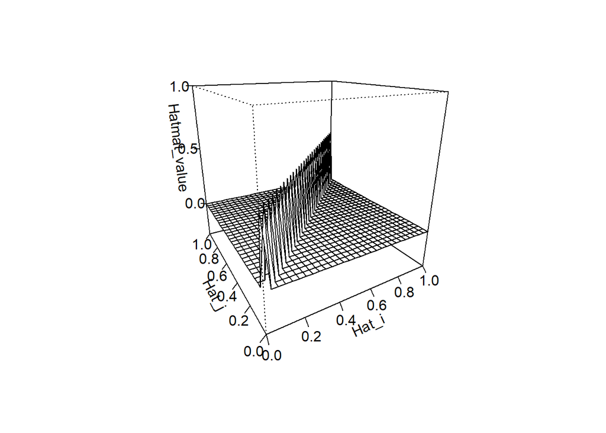

```
##                 [,1]           [,2]           [,3]           [,4]
##  [1,]   5.000000e-01   3.736335e-06  -2.792039e-11   2.086399e-16
##  [2,]   3.736335e-06   5.000000e-01   3.736335e-06  -2.792039e-11
##  [3,]  -2.792039e-11   3.736335e-06   5.000000e-01   3.736335e-06
##  [4,]   2.086399e-16  -2.792039e-11   3.736335e-06   5.000000e-01
##  [5,]  -1.559097e-21   2.086399e-16  -2.792039e-11   3.736335e-06
##  [6,]   1.165061e-26  -1.559097e-21   2.086399e-16  -2.792039e-11
##  [7,]  -8.706118e-32   1.165061e-26  -1.559097e-21   2.086399e-16
##  [8,]   6.505794e-37  -8.706118e-32   1.165061e-26  -1.559097e-21
##  [9,]  -4.861565e-42   6.505794e-37  -8.706118e-32   1.165061e-26
## [10,]   3.632887e-47  -4.861565e-42   6.505794e-37  -8.706118e-32
## [11,]  -2.714736e-52   3.632887e-47  -4.861565e-42   6.505794e-37
## [12,]   2.028632e-57  -2.714736e-52   3.632887e-47  -4.861565e-42
## [13,]  -1.515930e-62   2.028632e-57  -2.714736e-52   3.632887e-47
## [14,]   1.132804e-67  -1.515930e-62   2.028632e-57  -2.714736e-52
```

[output cut: 233 more lines]

```r
ydata <- c(9.6, 12.8, 14.6, 15.6 ,15.5 ,15.1, 15.6, 13.8, 13.9, 16.1, 17.3, 18, 19.9, 20, 19.9, 18.2, 15.8, 11.2, 9.6, 15.8, 16.7, 17.5, 13.7, 15.7, 20.6, 21.2, 16.7, 16, 20.7, 17.6)
xdata <- seq_len(length(ydata))

simple_krig_hat(xdata, 0.3, 1)
```

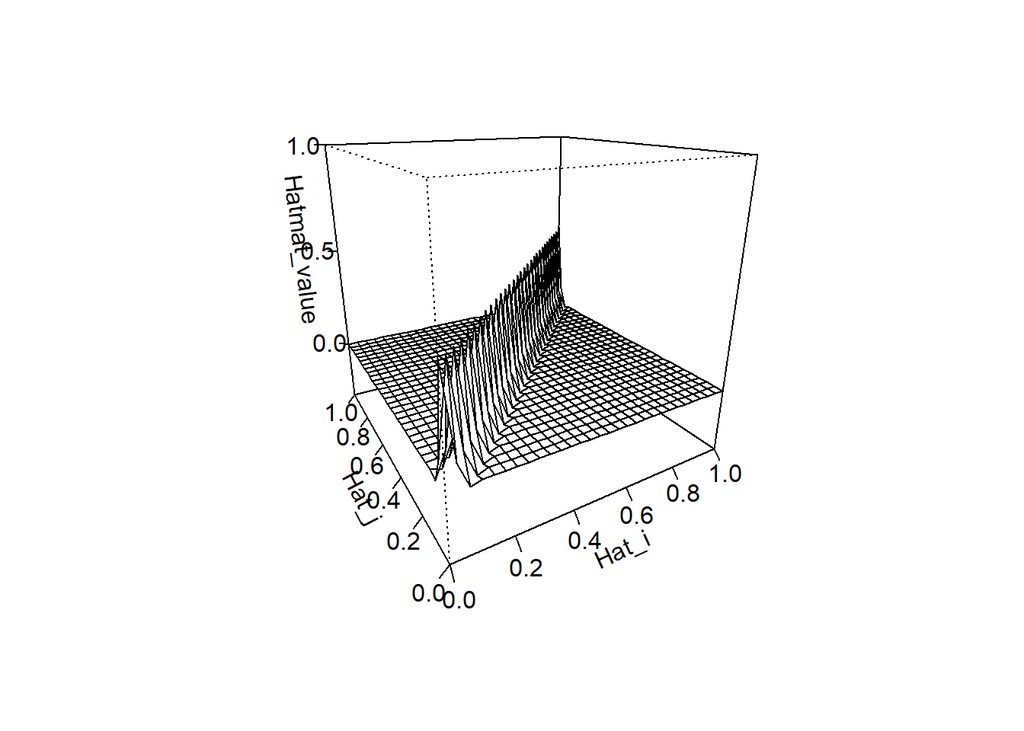

```
##                [,1]          [,2]          [,3]          [,4]
##  [1,]  4.821477e-01  9.772852e-02 -1.353774e-02  1.662161e-03
##  [2,]  9.772852e-02  4.637045e-01  1.002834e-01 -1.385142e-02
##  [3,] -1.353774e-02  1.002834e-01  4.633506e-01  1.003268e-01
##  [4,]  1.662161e-03 -1.385142e-02  1.003268e-01  4.633453e-01
##  [5,] -1.916561e-04  1.698330e-03 -1.385643e-02  1.003274e-01
##  [6,]  2.128326e-05 -1.956727e-04  1.698886e-03 -1.385650e-02
##  [7,] -2.306464e-06  2.171853e-05 -1.957330e-04  1.698894e-03
##  [8,]  2.458122e-07 -2.352854e-06  2.172496e-05 -1.957338e-04
##  [9,] -2.588967e-08  2.506981e-07 -2.353530e-06  2.172504e-05
## [10,]  2.703494e-09 -2.639987e-08  2.507688e-07 -2.353539e-06
## [11,] -2.805268e-10  2.756435e-09 -2.640721e-08  2.507697e-07
## [12,]  2.897120e-11 -2.859943e-10  2.757192e-09 -2.640730e-08
## [13,] -2.981295e-12  2.953383e-11 -2.860722e-10  2.757202e-09
## [14,]  3.059578e-13 -3.039035e-12  2.954183e-11 -2.860732e-10
```

[output cut: 233 more lines]

```r
simple_krig_hat(xdata, 1, 1)
```

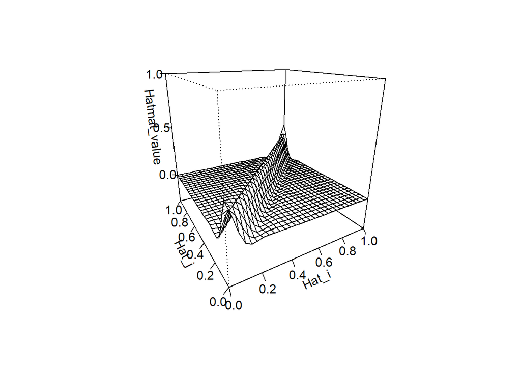

```
##                [,1]          [,2]          [,3]          [,4]
##  [1,]  3.590121e-01  2.435908e-01  1.023238e-01  7.707093e-03
##  [2,]  2.435908e-01  2.664417e-01  2.047053e-01  9.939493e-02
##  [3,]  1.023238e-01  2.047053e-01  2.501073e-01  2.034750e-01
##  [4,]  7.707093e-03  9.939493e-02  2.034750e-01  2.500147e-01
##  [5,] -2.137015e-02  1.582826e-02  1.028063e-01  2.037319e-01
##  [6,] -1.332261e-02 -1.630724e-02  1.795501e-02  1.029665e-01
##  [7,] -9.485690e-04 -1.296213e-02 -1.615581e-02  1.796642e-02
##  [8,]  3.210811e-03 -2.168754e-03 -1.347469e-02 -1.619442e-02
##  [9,]  1.864771e-03  2.502153e-03 -2.466436e-03 -1.349711e-02
## [10,]  4.197047e-05  1.848821e-03  2.495453e-03 -2.466941e-03
## [11,] -4.909702e-04  2.285510e-04  1.927197e-03  2.501356e-03
## [12,] -2.544340e-04 -3.942792e-04  2.691674e-04  1.930256e-03
## [13,]  8.544274e-06 -2.576811e-04 -3.956431e-04  2.690647e-04
## [14,]  7.389107e-05 -1.953610e-05 -2.694766e-04 -3.965316e-04
```

[output cut: 233 more lines]

```r
simple_krig_hat(xdata, 3, 1)
```

bandwidth가 커질수록, 데이터에서 먼 위치의 값들도 고려하게 되므로, diagonal entry의 hat matrix value는 줄어들고, diagonal entry에서 상대적으로 먼 위치에서의 값이 증가함을 알 수 있다.

## Q3

universal kriging을 이용해서 Q1과 같은 과정을 반복하자.

다만, polynomiaㅣ equation의 degree도 같이 optimized되어야 하므로, 이러한 과정을 진행해줄 수 있도록 위에서 구현한 함수를 살짝 바꿀것이다.

먼저,

```r
mykrig2<-function(nd, ne, xx, yy, ex, bw, np)
{
# (1)
  full <- matrix(0, nd, nd)
  full[lower.tri(full)] <- dist(xx)
  dist1 <- full + t(full)
  cc <- exp( - dist1^2/bw^2)
# (2)
  ll <- t(chol(cc))
  llr <- solve(ll)
# (3)
  powerf <- function(jj, x1)
  {
    pw <- x1^jj
    return(pw)
  }
  gg <- apply(matrix(c(0:(np - 1)), nrow = 1), 2, powerf,
    x1 = xx)
  aa <- qr(llr %*% gg)
  qq <- qr.Q(aa)
  rr <- qr.R(aa)
# (4)
  bb <- t(qq) %*% llr %*% yy
  beta1 <- solve(rr[1:np, ], bb[1:np])
# (5)
  dvector <- function(exs, xx, bw)
  {
    dv <- exp( - (exs - xx)^2/bw^2)
    return(dv)
  }
  dmat <- apply(matrix(ex, nrow = 1), 2, dvector, xx = xx,
    bw = bw)
# (6)
  ccr <- solve(cc)
  almat <- ccr %*% dmat
# (7)
  mm <- as.vector(beta1 %*% t(gg))
  exmat <- t(apply(matrix(c(0:(np - 1)), nrow = 1), 2,
    powerf, x1 = ex))
  ey <- beta1 %*% exmat + as.vector(t(almat) %*% (yy - mm))
# (8)
  return(ey)
}
```

먼저, 교재의 4장 (G) 부분에 해당하는 코드를 이용하여 polynomial 함수를 이용한 universal kriging을 구해주는 함수를 구현하였다.

즉, 다음과 같은 모델을 사용한다.

$y = \sum_{j=0}^{p-1} \beta_j g_j(x) + e$, 여기서 $g_j(x) = x^j$가 된다.

여기서 kriging에 사용하는 theoretical correlogram은

gaussian correlogram으로, 다음과 같다.

$Correlo(r) = \text{exp}(-(\frac{r}{\delta})^2)$

위 함수는 데이터인 xx, yy와 데이터의 개수인 nd, 추정할 데이터의 위치인 ex와 그 개수인 ne, 그리고 위의 theoretical correlogram에서 사용할 $\delta$인 bw와 polynomial의 차수인 np (정확히는 np-1 차수의 polynomial을 사용함)을 받아 ex의 위치에서 함수로 polynomial function을 사용한, universal kriging된 결과를 리턴해주는 함수이다.

이제, 위 함수를 사용하여 Q1과 같이, polynomial과 bandwidth를 바꿔가면서 CV를 가장 작게만드는 차수와 bandwidth를 찾고, kriging된 결과를 출력해보자.

먼저, bandwidth들과 polynomial들의 차수를 받아서 각 값에 해당하는 CV값들을 계산해주는 함수를 만든다.

```r
cv_univ_pol_krig<-function(xdata, ydata, bws, pols)
{
    nd <- length(ydata)

    ydata <- ydata[order(xdata)]
    xdata <- xdata[order(xdata)]
    #sort by ascending order. order of ydata, xdata is important!!


    get_univ_pol_krig_cv <- function(bw, pol, x1, y1)
    {
        cv <- 0
        nd <- length(y1)

        if(nd < 3) return(NULL) # we can't get cv

        for(i in seq(from = 2, to = nd-1))
        {
            xdata <- x1[-i]
            ydata <- y1[-i]
            remain_xdata <- x1[i]
            remain_ydata <- y1[i]
            estim_y <- mykrig2(nd-1, 1, xdata, ydata, as.vector(remain_xdata), bw, pol)
            cv <- cv + sum((remain_ydata - estim_y)**2)
        }

        cv <- cv / (nd - 2)
        return(cv)
    }

    cvmat <- matrix(nrow = length(bws), ncol = length(pols))
    for(i in seq_len(length(pols)))
    {
       cvlst <- lapply(as.list(bws),get_univ_pol_krig_cv, pol = pols[i], x1 = xdata, y1 = ydata)
       cvlst <- unlist(cvlst)
       cvmat[,i] <- cvlst
    }

    return(cvmat)
}
```

아래함수는 bandwidth, polynomial 들과 cv matrix를 받아서 그래프를 출력해주는 함수다.

```r
plot_2d_cv <- function(bandwidth_array, pol_array, cv_mat, description = "")
{
    par(mfrow = c(1, 1))
    persp(cv_mat, xlab = "bandwidth", ylab = "poly_degree", zlab = "cv", theta = -30, phi = 20, lab = c(3,3,3))

}
```

plot univ krig graph함수는 xdata, ydata, bw, pol을 받아 xdata의 위치에서, 원래 데이터를 점으로, estimate된 결과를 파란 선으로 그려준다.

```r
plot_univ_krig_graph <- function(xdata, ydata, bw, pol, description = "")
{
    par(mfrow=c(1,1))
    estimated_y <- mykrig2(length(xdata), length(xdata), xdata, ydata, xdata, bw, pol)
    plot(xdata, ydata , xlab = "X", ylab = "Y", type = "p", main = description, sub = sprintf("using bw : %f, pol = %d", bw, pol))
    lines(xdata, estimated_y, col = "blue")
}
```

마지막으로, xdata와 ydata, bandwidth, polynomial degree 목록을 받아서 이중 가장 CV값이 낮은 parameter를 사용한 kriging 그래프를 출력해주는 함수를 다음과 같이 구현하였다.

```r
full_test_univ_kriging <- function(xdata, ydata, smtparam_array, pol_array, description = "")
{
    cv_mat <- cv_univ_pol_krig(xdata, ydata, smtparam_array, pol_array)
    plot_2d_cv(smtparam_array, pol_array, cv_mat, description)

    smt_idx <- which(cv_mat == min(cv_mat, na.rm = TRUE),arr.ind = TRUE)

    if(length(smt_idx) > 1)
    {
        smt_idx <- smt_idx[1,]
    }

    bw_idx <- smt_idx[1]
    pol_idx <- smt_idx[2]

    best_bw <- smtparam_array[bw_idx]
    best_pol <- pol_array[pol_idx]

    plot_univ_krig_graph(xdata, ydata, best_bw, best_pol, description = description)
}
```

problem 2.3의 chapter 2의 데이터는 eqispaced data로, x값으로 1,2…의 값을 가지게 된다.

해당 데이터를 생성하고, 위 함수를 이용하여 가장 CV값을 낮게 만드는 $\delta$를 찾자.

delta의 값으로는 0.01~2까지, 0.01 간격의 값을 주었고 polynomial은 0차~4차까지를 사용하였다.

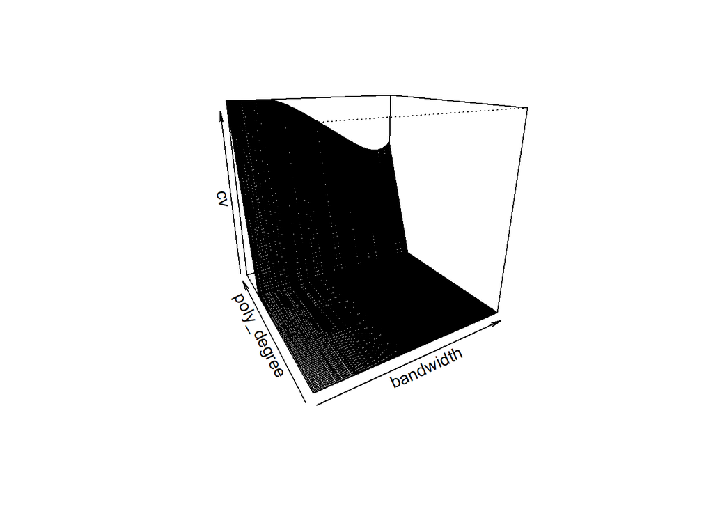

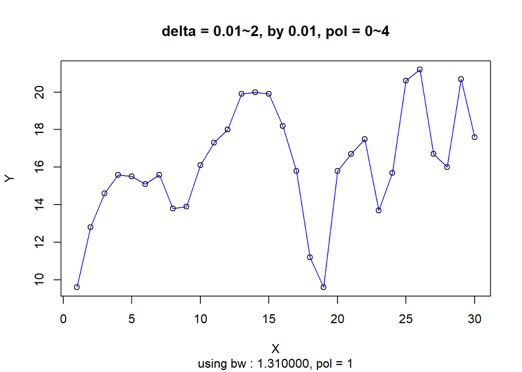

```r
ydata <- c(9.6, 12.8, 14.6, 15.6 ,15.5 ,15.1, 15.6, 13.8, 13.9, 16.1, 17.3, 18, 19.9, 20, 19.9, 18.2, 15.8, 11.2, 9.6, 15.8, 16.7, 17.5, 13.7, 15.7, 20.6, 21.2, 16.7, 16, 20.7, 17.6)
xdata <- seq_len(length(ydata))


full_test_univ_kriging(xdata, ydata, seq(0.01,2,by = 0.01),seq(1,5) ,description = "delta = 0.01~2, by 0.01, pol = 0~4")
```

pol-1이 degree 이므로, 결과로 알수 있듯이, degree가 0차, bandwidth가 1.31일때 가장 CV값이 낮음을 알 수 있다.

즉, ordinary kriging이 가장 효율적이고, 이때의 bandwidth가 1.31이 되어야함을 알 수 있었다.

## Q4

### 4-(a)

$$X = \left(\begin{array}{ccccccccc}
1 & X_{11} & X_{11}^{2} & \ldots & X_{11}^{p} & X_{12} & X_{12}^{2} & \ldots & X_{12}^{q} \\
1 & X_{21} & X_{21}^{2} & \ldots & X_{21}^{p} & X_{22} & X_{22}^{2} & \ldots & X_{22}^{q} \\
\vdots & \vdots & \vdots & \ddots & \vdots & \vdots & \vdots & \ddots & \vdots \\
1 & X_{n 1} & X_{n 1}^{2} & \ldots & X_{n 1}^{p} & X_{n 2} & X_{n 2}^{2} & \ldots & X_{n 2}^{q}
\end{array}\right)$$

$$\beta = \left(\begin{array}{c}
c_0 \\
c_1 \\
\vdots \\
c_p \\
d_1 \\
\vdots \\
d_q\end{array}\right)$$

$$y = \left(\begin{array}{c}
y_1 \\
y_2 \\
\vdots \\
y_n \end{array}\right)$$

라 하면, (4.116)의 모델에서 y는 다음과 같이 쓸 수 있다.

$y = X\beta + e$

이때, $e_i$는 서로 독립이므로, $e \sim (0,\sigma^2 I_n)$이 성립한다. 즉, 평균이 0이고, 분산이 단위행렬의 실수배가 된다.

따라서, normal equation을 구하기 위해

$E_{p4} = ||y - X||^2 $을 최소화하는 $\beta$를 구하면 되는데, 이는 우리가 linear regression에서 많이 접해왔던 형태이므로, 이를 $\beta$로 미분한 값이 0이되는 $\beta$에서 최솟값을 가짐을 알고,

$||y - X\beta||^2 = (y - X\beta)^t (y - X\beta) = y^t y - 2\beta^tX^ty - \beta^t X^t X \beta$에서,

위 식을 $\beta$로 미분해서 0이되는 $\beta$는

$\frac{\partial E_{p4}}{\partial \beta} = - 2X^ty + 2 X^t X \beta = 0$ 에서, normal equation은 다음과 같은 형태이다. $X^t X \beta = X^ty$

추가적으로, $X^t X$가 non-singular matrix이면 $\hat{\beta} =(X^t X)^{-1} X^t y$임도 알고있다.

### 4-(b)

위 normal equation을 이용해서, regression coefficient인 $\hat{\beta}$를 구하는 함수를 짜고,

나아가 해당하는 hat matrix까지 구해주는 함수를 짜자.

hat matrix의 경우, $\hat{y} = X\hat{\beta} = X (X^t X)^{-1} X^t y$에서,

$H = X (X^t X)^{-1} X^t$임을 안다.

poly함수의 인자로 raw = TRUE를 주면, 받은 데이터를 degree만큼 제곱해서 확장한 matrix를 리턴해준다.

예를들어 poly(c(1,2,3), deg = 4, raw = TRUE)를 실행하면,

첫번째 column은 1,2,3 , 두번째 column은 1,4,9, 세번째 column은 1,8,27, 네번째 column은 1,16,81인 matrix를 리턴해주므로

다음함수는 이를 이용하여 design matrix를 만들어서 리턴해준다.

```r
get_design_mat_two_predictor <- function(x1data, x2data, deg1, deg2, raw = FALSE)
{
    if(raw == FALSE)
    {
        X <- matrix(rep(1/sqrt(length(x1data)), length(x1data)), nrow = length(x1data), ncol = 1)
        d1 <- poly(x1data, degree = deg1, raw = FALSE)
        d2 <- poly(x2data, degree = deg2, raw = FALSE)
        X <- cbind(X,d1,d2)
        return(X)
    }
    else
    {
        X <- matrix(rep(1, length(x1data)), nrow = length(x1data), ncol = 1)
        d1 <- poly(x1data, degree = deg1, raw = TRUE)
        d2 <- poly(x2data, degree = deg2, raw = TRUE)
        X <- cbind(X,d1,d2)
        return(X)
    }
}
```

다음 함수는 x1data와 x2data, ydata를 받고, 각 x1,x2의 차수를 받아

위와 같은 normal equation을 이용해 $\hat{beta}$를 구해준다.

```r
additive_reg_coef_raw <- function(x1data, x2data, ydata, deg1, deg2)
{
    # first, make design matrix
    X <- get_design_mat_two_predictor(x1data, x2data, deg1, deg2, raw = TRUE)

    # next, get beta = (X'X)^-1X'y

    y <- matrix(ydata, nrow = length(ydata), ncol = 1)

    beta = solve(t(X) %*% X, t(X) %*% y)
    # solve(A,b) return A^-1 b.

    return(beta)
}
```

또한, hat matrix역시 다음과 같이 구할 수 있다. hat matrix를 구할때는 ydata는 필요하지 않다.

```r
additive_hat_mat_raw <- function(x1data, x2data, deg1, deg2)
{
    # first, make design matrix
    X <- get_design_mat_two_predictor(x1data, x2data, deg1, deg2, raw = TRUE)

    # next, get H = X(X'X)^-1X'

    hat = X %*% solve(t(X) %*% X) %*% t(X)
    # solve(A) return A^-1.

    return(hat)
}
```

이렇게 구현한 함수를 다음과 같이 테스트 해볼 수 있다.

$Y_i = sin(0.2 \pi X_{i1}) + 0.05 X_{i2}^2 - 0.4 X_{i2} + 3 + e_i$, $e_i \sim N(0, 0.1^2)$이고, $e_i$들의 분포가 서로 독립인 데이터를 이용해서,

$Y_i = c_0 + \sum_{i=1}^p c_i X_{i1}^i + \sum_{i=1}^q d_i X_{i2}^i$

p = 4, q = 2

와 같은 모델을 이용하여 추정한 coefficient들과 hat matrix는 다음과 같다.

```r
# (1)
nd <- 40
# (2)
set.seed(100)
xx1 <- runif(nd, min =0, max = 10)
xx2 <- runif(nd, min =0, max = 10)
yy <- sin(0.2 * pi * xx1) + xx2^2 * 0.05 - xx2 * 0.4 +
  3 + rnorm(nd, mean = 0, sd = 0.1)
# (3)
deg1 <- 4
deg2 <- 2
reg_coef_raw <- additive_reg_coef_raw(xx1, xx2, yy, deg1, deg2)
reg_hat_raw <- additive_hat_mat_raw(xx1, xx2, deg1, deg2)

reg_coef_raw
```

```
##            [,1]
##    2.3389918834
## 1  1.4373069398
## 2 -0.3894209717
## 3  0.0243278717
## 4  0.0001102478
## 1 -0.3545429132
## 2  0.0466388309
```

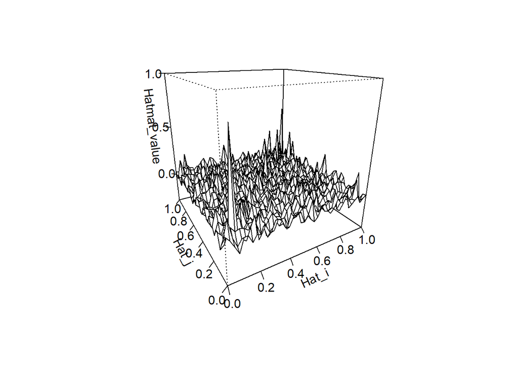

```r
plot_hatmat(reg_hat_raw)
```

### 4-(c)

$$\left(\begin{array}{cccccccc}
r_{0}\left(X_{11}\right) & r_{1}\left(X_{11}\right) & r_{2}\left(X_{11}\right) & \cdots & r_{p}\left(X_{11}\right) & s_{1}\left(X_{12}\right) & \cdots & s_{q}\left(X_{12}\right) \\
r_{0}\left(X_{21}\right) & r_{1}\left(X_{21}\right) & r_{2}\left(X_{21}\right) & \cdots & r_{p}\left(X_{21}\right) & s_{1}\left(X_{22}\right) & \cdots & s_{q}\left(X_{22}\right) \\
\vdots & \vdots & \vdots & \ddots & \vdots & \vdots & \ddots & \vdots \\
r_{0}\left(X_{n 1}\right) & r_{1}\left(X_{n 1}\right) & r_{2}\left(X_{n 1}\right) & \cdots & r_{p}\left(X_{n 1}\right) & s_{1}\left(X_{n 2}\right) & \cdots & s_{q}\left(X_{n 2}\right)
\end{array}\right)$$

위와 같은 design matrix를 사용해야 한다. 이때, $r_0(.) = \frac{1}{\sqrt{n}}$, $<r_i,r_j> = \delta_{ij}, <s_i,s_j> = \delta_{ij}, \delta_{ij}= I(i=j)$ 가 성립한다. 즉, $r_i$들과 $s_i$들은 orthogoanl polynomial이다.

이때, poly 함수를 이용하면, 각각 $r_j(X_{i1})$와 $s_j(X_{i2})$에 해당하는, orthogonal polynomial들의 값들을 생성해주므로, 위에서 구현한 get_design_mat_two_predictor에 raw 인자를 FALSE로 주면, 위와 같은 design matrix를 받아올 수 있다.

따라서, 위 design matrix를 사용하여 각각의 coefficient와 hat matrix를 리턴하는 함수를 짜면,

```r
additive_reg_coef <- function(x1data, x2data, ydata, deg1, deg2)
{
    # first, make design matrix
    X <- get_design_mat_two_predictor(x1data, x2data, deg1, deg2, raw = FALSE)

    # next, get beta = (X'X)^-1X'y

    y <- matrix(ydata, nrow = length(ydata), ncol = 1)

    beta = solve(t(X) %*% X, t(X) %*% y)
    # solve(A,b) return A^-1 b.

    return(beta)
}
```

```r
additive_hat_mat <- function(x1data, x2data, deg1, deg2)
{
    # first, make design matrix
    X <- get_design_mat_two_predictor(x1data, x2data, deg1, deg2, raw = FALSE)

    # next, get H = X(X'X)^-1X'

    hat = X %*% solve(t(X) %*% X) %*% t(X)
    # solve(A) return A^-1.

    return(hat)
}
```

```r
# (1)
nd <- 40
# (2)
set.seed(100)
xx1 <- runif(nd, min =0, max = 10)
xx2 <- runif(nd, min =0, max = 10)
yy <- sin(0.2 * pi * xx1) + xx2^2 * 0.05 - xx2 * 0.4 +
  3 + rnorm(nd, mean = 0, sd = 0.1)
# (3)
deg1 <- 4
deg2 <- 2
reg_coef <- additive_reg_coef(xx1, xx2, yy, deg1, deg2)
reg_hat <- additive_hat_mat(xx1, xx2, deg1, deg2)

reg_coef
```

```
##          [,1]
##   16.26000948
## 1 -3.80061611
## 2  0.76799668
## 3  2.59191361
## 4  0.02656535
## 1  2.26023827
## 2  1.62748066
```

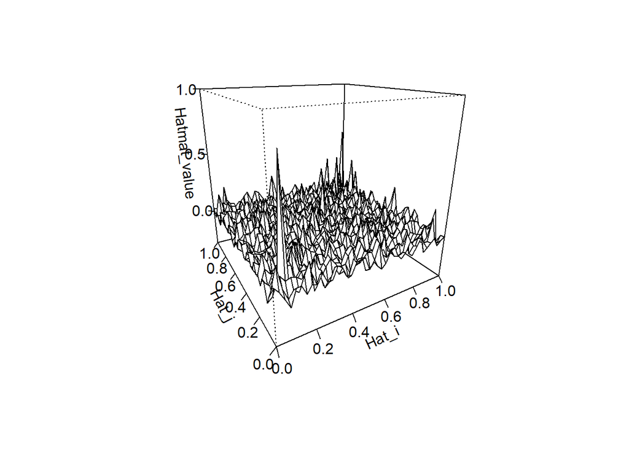

```r
plot_hatmat(reg_hat)
```

각각의 coefficient와 hat matrix를 plot한 결과는 위와 같다.

### 4-(d)

simulation data를 이용하여 계삲나 두 경우의 hat matrix가 같음을 보이자.

위에서 구한 두 hat matrix의 차이를 보이면 된다.

```r
max(abs(reg_hat - reg_hat_raw))
```

```
## [1] 2.649991e-12
```

위와 같이, 두 hat matrix의 성분들의 차이의 절댓값중 가장 큰값이 $2.65 * 10^{-12}$로, 매우 작은 값임을 알 수 있다.

따라서 두 matrix의 각 성분들의 차이는 거의 없다고 봐도 될 정도임을 보였고,

즉, 두 hat matrix가 같음을 보였다.

## Q5

4장 (M) 부분의 함수는 다음과 같다. (eval = FALSE로 실행되지 않는 코드임)

```r
##(M) Derivation of a regression equation with the form
## of ACE by solving an eigenvalue problem using iterative calculation
aceit1<-function(nd, it, npx1, npx2, npy, xx1, xx2, yy)
{
# (1)
  yyst <- yy
# (2)
  powerf <- function(jj, x1)
  {
    pw <- x1^jj
    return(pw)
  }
  xxm1 <- apply(matrix(c(1:npx1), nrow = 1),
    2, powerf, x1 = xx1)
  xxm2 <- apply(matrix(c(1:npx2), nrow = 1),
    2, powerf, x1 = xx2)
  xxmat <- cbind(xxm1, xxm2)
  xxmean <- apply(xxmat, 2, mean)
  xxmat <- sweep(xxmat, 2, xxmean)
  yymat <- apply(matrix(c(1:npy), nrow = 1),
    2, powerf, x1 = yy)
  yymean <- apply(yymat, 2, mean)
  yymat <- sweep(yymat, 2, yymean)
  hatx <- xxmat %*% solve (crossprod (xxmat)) %*% t(xxmat)
  haty <- yymat %*% solve(crossprod(yymat)) %*% t(yymat)
  hatyx <- haty %*% hatx
# (3)
  for(ii in 1 :it) {
    yyst <- hatyx %*% yyst
    yyst <- (sqrt(nd) * yyst)/sqrt(sum(yyst^2))
  }
# (4)
  return(yyst)
}
```

위 함수를 적당히 고쳐서, smoothing spline을 각 variable의 smoother로 사용하도록 고쳐보자.

ACE에서 가정하는 모형은 $\eta(Y_i) = m_1(X_{i1}) + m_2(X_{i2}) + \epsilon_i$ 이므로,

이 모형을 fit하기 위해 addtive model을 이용해서, ACE 알고리즘을 실행하면,

1. 표준화된 $Y_i$들을 $Y_i^* = \frac{Y_i - \bar{Y_i}}{sd(Y_i)}$라 하고,
2. 데이터 $\{(X_{i1}, X_{i2}, Y_i^*)\}$을 사용하여 $m_1(X_{i1}) + m_2(X_{i2})$을 $y_i^*$로, $\hat{Y_i^*}$을 추정한다.
3. 그 후, 데이터 $\{(Y_i, \hat{Y_i^*})\}$을 사용하여 $\eta(Y_i)$를 $\hat{y_i^*}$로, $\tilde{Y_i^*}$ 를 추정하고,
4. 이 $\tilde{Y_i^*}$을 다시 표준화해서, $Y_i^*$을 다시 정의한다.

그 후 2~4를 충분히 반복해서, 최종 추정값으로 $Y_i^{*(k)}$를 사용하게 된다.

이때, 2번을 하는 과정은 $Y^*$에 $H_X$를 곱하는것과 같고,

3번을 하는 과정은 $H_X y^*$에 $H_Y$를 곱하는것과 같으므로,

결국 2~3번 과정은 $H_Y H_X y^*$을 적용하는것과 같다.

또한, 여기서 standard deviation을 다음과 같이 쓸수 있으므로, $sd(\{ \tilde{Y_i} \}) = \frac{||\tilde{y^*}||}{\sqrt{n}}$

위 코드를 통해 ACE 알고리즘이 돌아갈 수 있는것이다.

이 과정을 위 함수를 수정해서 적용해보자.

hatmatrix를 사용해야 하므로, smoothing spline의 hat matrix를 구해야 한다.

$Y_i$측면에서 구하는것은 predictor가 1개이므로 구하기 쉽지만, $X_{i1}$ , $X_{i2}$인 case에서 smoothing spline의 hat matrix를 구하려면, 약간의 조작이 필요하다.

이때, $\hat{y} = Hy$에서 $y = e_i$, $e_i$는 ith member가 1, 그 외의 성분이 모두 0 인 n x 1 vector일때, 결과로 나오는것이 $H$의 ith column이므로, 이를 이용하여 hat matrix를 구할것이다.

아래 함수는 xdata1, xdata2, lambx1, lambx2를 받아 $m_1(x_1) + m_2(x_2)$에서, 각각의 $m(x)$가 smoothing spline일때, 이에 해당하는 hat matrix를 리턴해준다.

이때 $m_1(x)$의 smoothing parameter는 lambx1, $m_2(x)$의 smoothing parameter는 lambx2이다.

```r
hat_smoothing_spline_two <- function(xdata1, xdata2, lambx1, lambx2)
{
    nd <- length(xdata1)
    I_n <- diag(nd)
    hatmat <- matrix(nrow = nd, ncol = nd)

    for(i in 1:nd) {
        ydata <- I_n[, i]

        fit.sp1 <- smooth.spline(xdata1, ydata, lambda = lambx1, all.knots = TRUE)
        fit.sp2 <- smooth.spline(xdata2, ydata, lambda = lambx2, all.knots = TRUE)

        pred1 <- predict(fit.sp1, xdata1)
        pred2 <- predict(fit.sp2, xdata2)

        estim_y <- pred1$y + pred2$y
        hatmat[,i] <- estim_y
    }
    return(hatmat)
}
```

마찬가지로, 아래 함수는 ydata, lambda를 받아 $\eta(y)$에서, $\eta(y)$가 smoothing spline일때, 이에 해당하는 hat matrix를 리턴해준다.

```r
hat_smoothing_spline_one <- function(xdata, lamb)
{
    nd <- length(xdata)
    I_n <- diag(nd)
    hatmat <- matrix(nrow = nd, ncol = nd)

    for(i in 1:nd) {
        ydata <- I_n[, i]

        fit.sp1 <- smooth.spline(xdata, ydata, lambda = lamb, all.knots = TRUE)

        pred <- predict(fit.sp1, xdata)

        estim_y <- pred$y
        hatmat[,i] <- estim_y
    }
    return(hatmat)
}
```

따라서, 위와 같이 hat matrix를 만들 수 있으므로,

이제 맨 처음 도입했던 함수를 적절히 고치자.

아래 함수는 data의 개수 nd, iteration 회수 it, data에 해당하는 xx1, xx2, yy를 받고,

x1, x2, y에 해당되는 labmda를 받아, iteration 회수만큼 ACE 알고리즘을 돌린 결과를 리턴해준다.

```r
##(M) Derivation of a regression equation with the form
## of ACE by solving an eigenvalue problem using iterative calculation
aceit1_smooth<-function(nd, it, xx1, xx2, yy, lambx1, lambx2, lamby)
{
# (1)
  yyst <- (yy - mean(yy))/sqrt(sum((yy - mean(yy))^2)/nd) # need to calculate this!

  hatx <- hat_smoothing_spline_two(xx1, xx2, lambx1, lambx2)
  haty <- hat_smoothing_spline_one(yy, lamby)
  hatyx <- haty %*% hatx
# (3)
  for(ii in 1:it) {
    yyst <- hatyx %*% yyst
    yyst <- (sqrt(nd) * yyst)/sqrt(sum(yyst^2))
  }
# (4)
  return(yyst)
}
```

위와 같이 고칠 수 있다.

이제, 이렇게 만들어진 object를 사용해서 test를 해보자.

책에서 aceit1 부분을 test하는 코드를 약간 바꿔 사용하였다.

각 lambda로는 모두 0.01을 사용하였다.

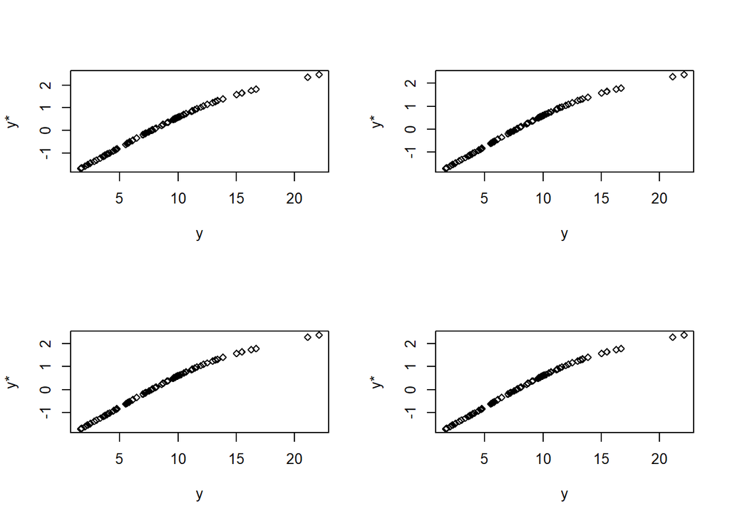

```r
nd <- 100
set.seed(100)
xx1 <- runif(nd, min =0, max = 10)
xx2 <- runif(nd, min =0, max = 10)
yy <- (sin(0.2 * pi * xx1) + xx2^2 * 0.05 - xx2 * 0.4
  + 3 + rnorm(nd, mean =0, sd = 0.1))^2
# (2)
lambx1 <- 0.01
lambx2 <- 0.01
lamby <- 0.01
# (3)
par(mfrow = c(2, 2))
# (4)
for(it in 1:4) {
  yyst <- aceit1_smooth(nd, it, xx1, xx2, yy, lambx1, lambx2, lamby)
  plot(yy, yyst, type = "n", xlab = "y", ylab = "y*")
  points(yy, yyst, cex = 0.7, pch =5)
  }
```

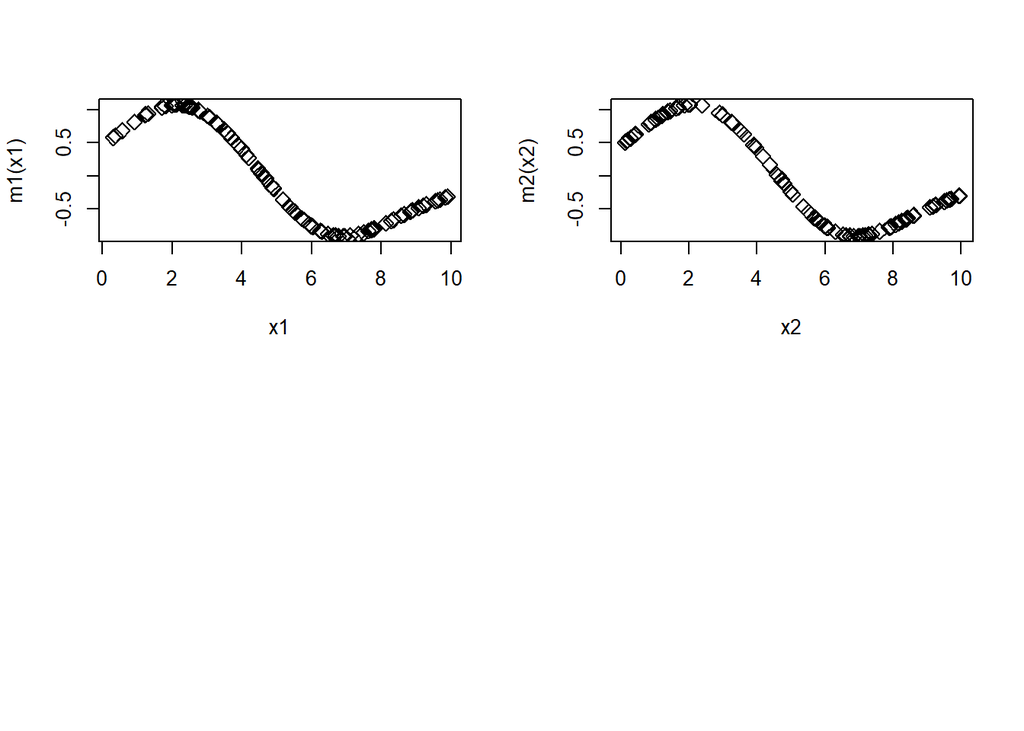

```r
fit.sp1 <- smooth.spline(xx1, yyst, lambda = lambx1, all.knots = TRUE)
fit.sp2 <- smooth.spline(xx1, yyst, lambda = lambx2, all.knots = TRUE)

fit.tmd1 <- predict(fit.sp1, xx1)
fit.tmd2 <- predict(fit.sp2, xx2)
eyd1 <- fit.tmd1$y
eyd2 <- fit.tmd2$y
yhat <- eyd1 + eyd2
plot(xx1, eyd1, type = "n", xlab = "x1", ylab = "m1(x1)")
points(xx1, eyd1, cex = 1.2, pch =5)
plot(xx2, eyd2, type = "n", xlab = "x2", ylab = "m2(x2)")
points(xx2, eyd2, cex = 1.2, pch =5)
```

iterate 횟수에 따른 y의 추정값과, iterate가 4번 된 결과로 나온 $m_1(x_1), m_2(x_2)$의 결과가 출력되었다.

만약, lambda를 바꾼다면 다음과 같이 fit되는것을 볼 수 있다.

x1의 lambda를 0.001로, x2의 lambda를 0.03, y의 lambda를 0.003으로 주었다.

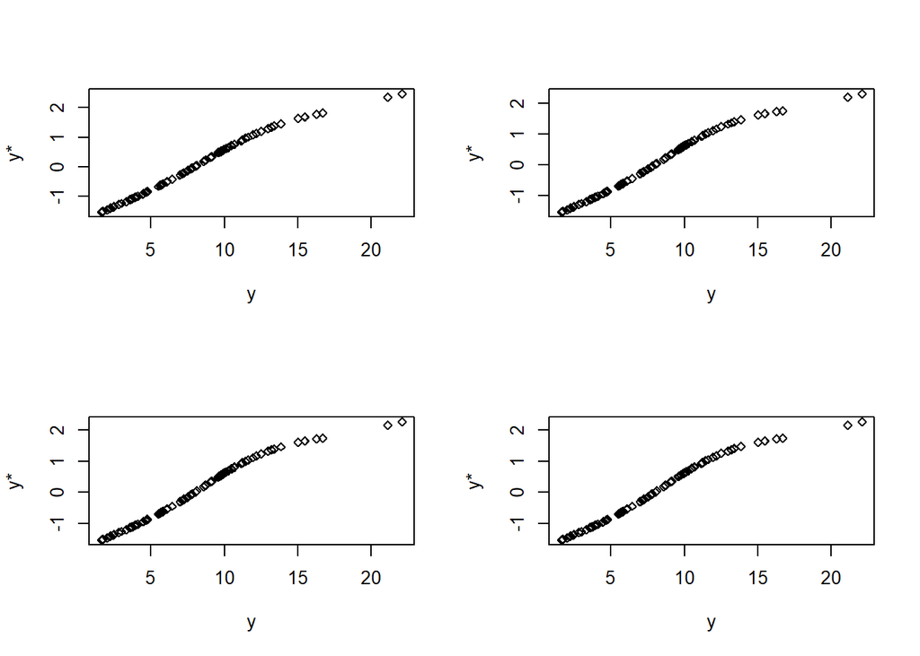

```r
nd <- 100
set.seed(100)
xx1 <- runif(nd, min =0, max = 10)
xx2 <- runif(nd, min =0, max = 10)
yy <- (sin(0.2 * pi * xx1) + xx2^2 * 0.05 - xx2 * 0.4
  + 3 + rnorm(nd, mean =0, sd = 0.1))^2
# (2)
lambx1 <- 0.001
lambx2 <- 0.03
lamby <- 0.003
# (3)
par(mfrow = c(2, 2))
# (4)
for(it in 1:4) {
  yyst <- aceit1_smooth(nd, it, xx1, xx2, yy, lambx1, lambx2, lamby)
  plot(yy, yyst, type = "n", xlab = "y", ylab = "y*")
  points(yy, yyst, cex = 0.7, pch =5)
  }
```

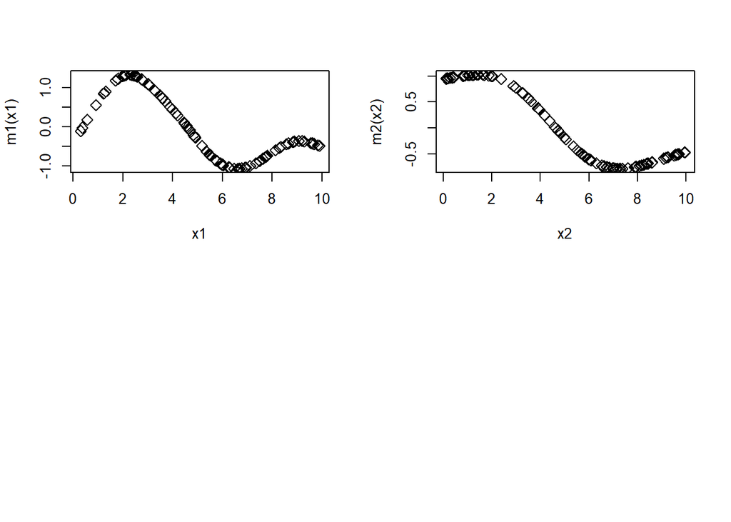

```r
fit.sp1 <- smooth.spline(xx1, yyst, lambda = lambx1, all.knots = TRUE)
fit.sp2 <- smooth.spline(xx1, yyst, lambda = lambx2, all.knots = TRUE)

fit.tmd1 <- predict(fit.sp1, xx1)
fit.tmd2 <- predict(fit.sp2, xx2)
eyd1 <- fit.tmd1$y
eyd2 <- fit.tmd2$y
yhat <- eyd1 + eyd2
plot(xx1, eyd1, type = "n", xlab = "x1", ylab = "m1(x1)")
points(xx1, eyd1, cex = 1.2, pch =5)
plot(xx2, eyd2, type = "n", xlab = "x2", ylab = "m2(x2)")
points(xx2, eyd2, cex = 1.2, pch =5)
```